# Random walk IBM tutorials (Results)

This page contains the solutions to the scenarios requested in the random walk IBM tutorial. It starts by presenting the base case, and then changes one (or more) parameter(s) at a time. Results are collapsed by default, but you can expand them to interpret the new dynamics. Good luck!

To start, please load the IBM functions we prepared on the GitHub repository.

If the `curl` packages is not installed yet, you can do so by:

```r
install.packages(curl) # install the curl library (to import data)
```

```r
# load package 'curl'
library('curl')

# download R file with IBM function
curl_download("https://github.com/lwillem/modelling-intro/raw/master/lib/ibm_functions.R",
              destfile = "ibm_functions.R")

# load the IBM functions
source('ibm_functions.R')
```

# Base case scenario

```r
# you can run the random walk IBM with default parameters (see console)
run_ibm_random_walk(rng_seed = 2000)
```

**Show plot**

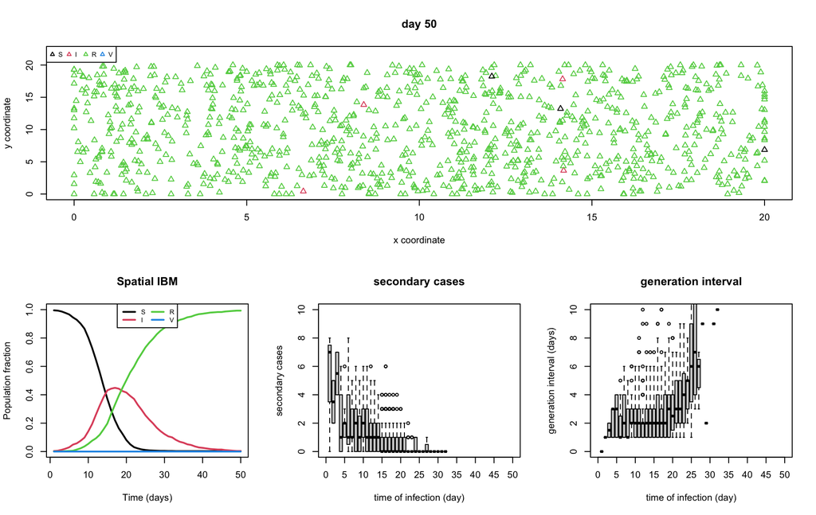

**Show output**

```
## [1] "MODEL PARAMETERS"
## [1] "pop_size: 1000"
## [1] "num_days: 50"
## [1] "num_infected_seeds: 3"
## [1] "vaccine_coverage: 0"
## [1] "apply_spatial_vaccine_refusal: FALSE"
## [1] "rng_seed: 2000"
## [1] "area_size: 20"
## [1] "max_step_size: 1"
## [1] "target_num_contacts_day: 10"
## [1] "max_contact_distance: 2"
## [1] "num_days_infected: 7"
## [1] "transmission_prob: 0.1"
## [1] "plot_time_delay: 0"
## [1] "-------------"
## [1] "MODEL RESULTS"
## [1] "total incidence: 100%"
## [1] "Peak prevalence: 45%"
## [1] "Peak day:        17"
## [1] "Total run time:  3s"
```

# Start with 10 infected individuals (instead of 3)

```r
run_ibm_random_walk(num_infected_seeds = 10,
                    rng_seed = 2000,
                    add_baseline = T)
```

**Show plot**

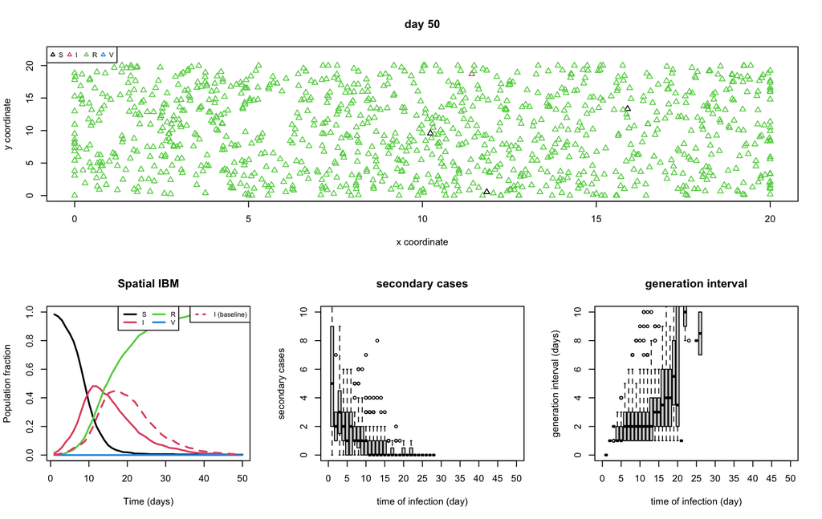

**Show output**

```
## [1] "MODEL PARAMETERS"
## [1] "pop_size: 1000"
## [1] "num_days: 50"
## [1] "num_infected_seeds: 10"
## [1] "vaccine_coverage: 0"
## [1] "apply_spatial_vaccine_refusal: FALSE"
## [1] "rng_seed: 2000"
## [1] "area_size: 20"
## [1] "max_step_size: 1"
## [1] "target_num_contacts_day: 10"
## [1] "max_contact_distance: 2"
## [1] "num_days_infected: 7"
## [1] "transmission_prob: 0.1"
## [1] "plot_time_delay: 0"
## [1] "-------------"
## [1] "MODEL RESULTS"
## [1] "total incidence: 100%   [baseline: 100%]"
## [1] "Peak prevalence: 48%   [baseline: 45%]"
## [1] "Peak day:        11    [baseline: 17]"
## [1] "Total run time:  2s"
```

# Start with 50 infected individuals (instead of 3)

```r
run_ibm_random_walk(num_infected_seeds = 50,
                    rng_seed = 2000,
                    add_baseline = T)
```

**Show plot**

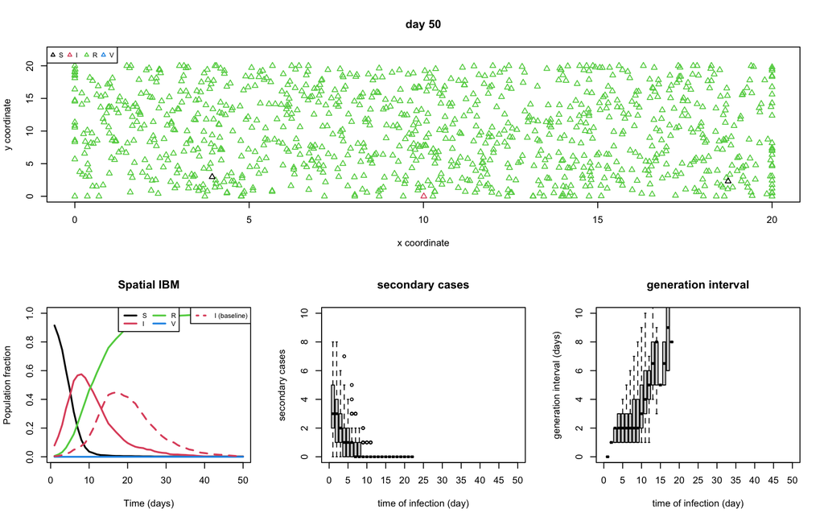

**Show output**

```
## [1] "MODEL PARAMETERS"
## [1] "pop_size: 1000"
## [1] "num_days: 50"
## [1] "num_infected_seeds: 50"
## [1] "vaccine_coverage: 0"
## [1] "apply_spatial_vaccine_refusal: FALSE"
## [1] "rng_seed: 2000"
## [1] "area_size: 20"
## [1] "max_step_size: 1"
## [1] "target_num_contacts_day: 10"
## [1] "max_contact_distance: 2"
## [1] "num_days_infected: 7"
## [1] "transmission_prob: 0.1"
## [1] "plot_time_delay: 0"
## [1] "-------------"
## [1] "MODEL RESULTS"
## [1] "total incidence: 100%   [baseline: 100%]"
## [1] "Peak prevalence: 57%   [baseline: 45%]"
## [1] "Peak day:        8    [baseline: 17]"
## [1] "Total run time:  2s"
```

# Number of days infected: 3 (instead of 7)

```r
run_ibm_random_walk(num_days_infected = 3,
                    rng_seed = 2000,
                    add_baseline = T)
```

**Show plot**

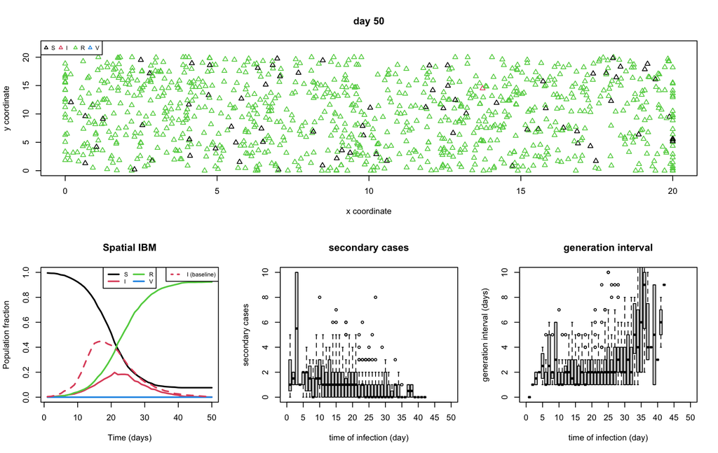

**Show output**

```
## [1] "MODEL PARAMETERS"
## [1] "pop_size: 1000"
## [1] "num_days: 50"
## [1] "num_infected_seeds: 3"
## [1] "vaccine_coverage: 0"
## [1] "apply_spatial_vaccine_refusal: FALSE"
## [1] "rng_seed: 2000"
## [1] "area_size: 20"
## [1] "max_step_size: 1"
## [1] "target_num_contacts_day: 10"
## [1] "max_contact_distance: 2"
## [1] "num_days_infected: 3"
## [1] "transmission_prob: 0.1"
## [1] "plot_time_delay: 0"
## [1] "-------------"
## [1] "MODEL RESULTS"
## [1] "total incidence: 92%   [baseline: 100%]"
## [1] "Peak prevalence: 20%   [baseline: 45%]"
## [1] "Peak day:        21    [baseline: 17]"
## [1] "Total run time:  1s"
```

# Number of days infected: 10 (instead of 7)

```r
run_ibm_random_walk(num_days_infected = 10,
                    rng_seed = 2000,
                    add_baseline = T)
```

**Show plot**

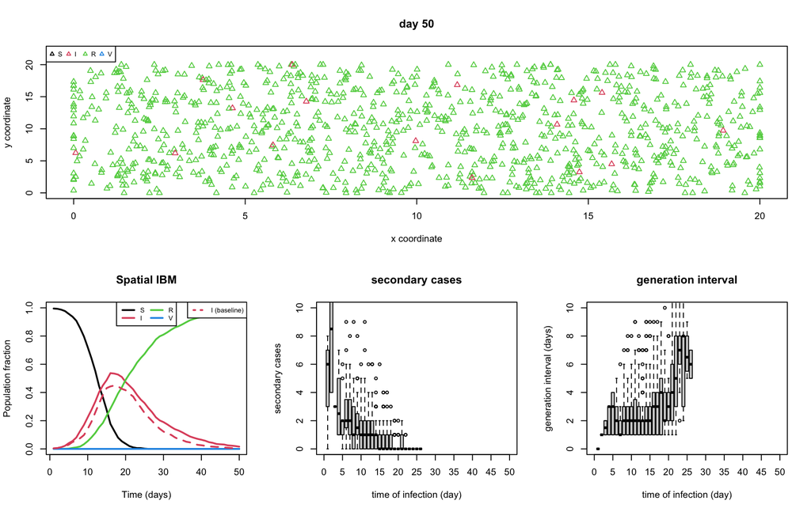

**Show output**

```
## [1] "MODEL PARAMETERS"
## [1] "pop_size: 1000"
## [1] "num_days: 50"
## [1] "num_infected_seeds: 3"
## [1] "vaccine_coverage: 0"
## [1] "apply_spatial_vaccine_refusal: FALSE"
## [1] "rng_seed: 2000"
## [1] "area_size: 20"
## [1] "max_step_size: 1"
## [1] "target_num_contacts_day: 10"
## [1] "max_contact_distance: 2"
## [1] "num_days_infected: 10"
## [1] "transmission_prob: 0.1"
## [1] "plot_time_delay: 0"
## [1] "-------------"
## [1] "MODEL RESULTS"
## [1] "total incidence: 100%   [baseline: 100%]"
## [1] "Peak prevalence: 54%   [baseline: 45%]"
## [1] "Peak day:        16    [baseline: 17]"
## [1] "Total run time:  2s"
```

# Population size 100 (instead of 1000)

```r
run_ibm_random_walk(pop_size = 100,
                    rng_seed = 2000,
                    add_baseline = T)
```

**Show plot**

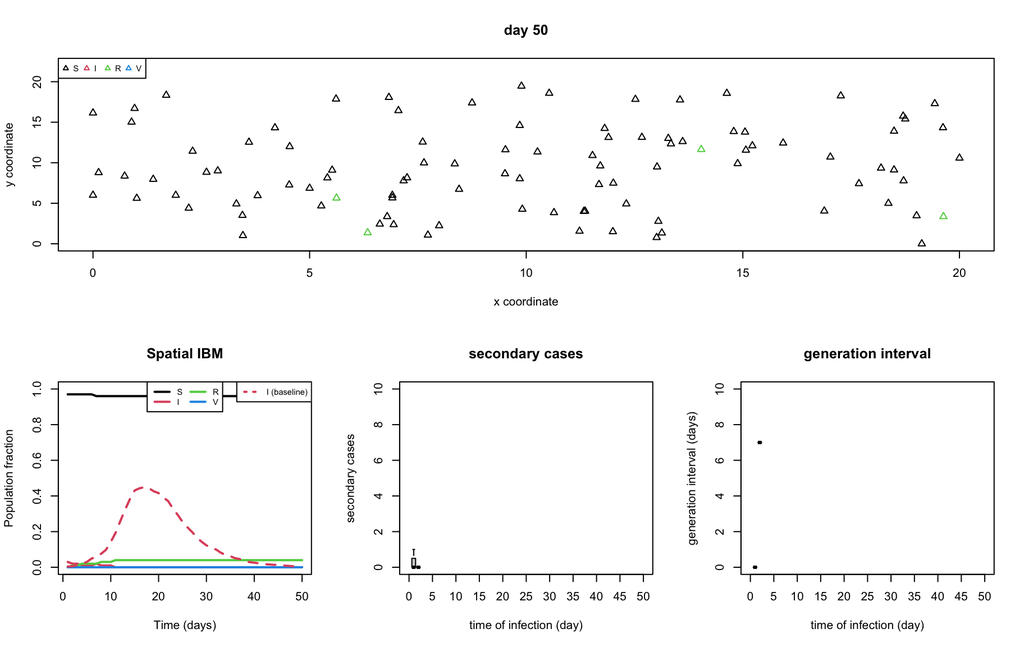

**Show output**

```
## [1] "MODEL PARAMETERS"
## [1] "pop_size: 100"
## [1] "num_days: 50"
## [1] "num_infected_seeds: 3"
## [1] "vaccine_coverage: 0"
## [1] "apply_spatial_vaccine_refusal: FALSE"
## [1] "rng_seed: 2000"
## [1] "area_size: 20"
## [1] "max_step_size: 1"
## [1] "target_num_contacts_day: 10"
## [1] "max_contact_distance: 2"
## [1] "num_days_infected: 7"
## [1] "transmission_prob: 0.1"
## [1] "plot_time_delay: 0"
## [1] "-------------"
## [1] "MODEL RESULTS"
## [1] "total incidence: 4%   [baseline: 100%]"
## [1] "Peak prevalence: 3%   [baseline: 45%]"
## [1] "Peak day:        1    [baseline: 17]"
## [1] "Total run time:  1s"
```

# Population size 2000 (instead of 1000)

```r
run_ibm_random_walk(pop_size = 2000,
                    rng_seed = 2000,
                    add_baseline = T)
```

**Show plot**

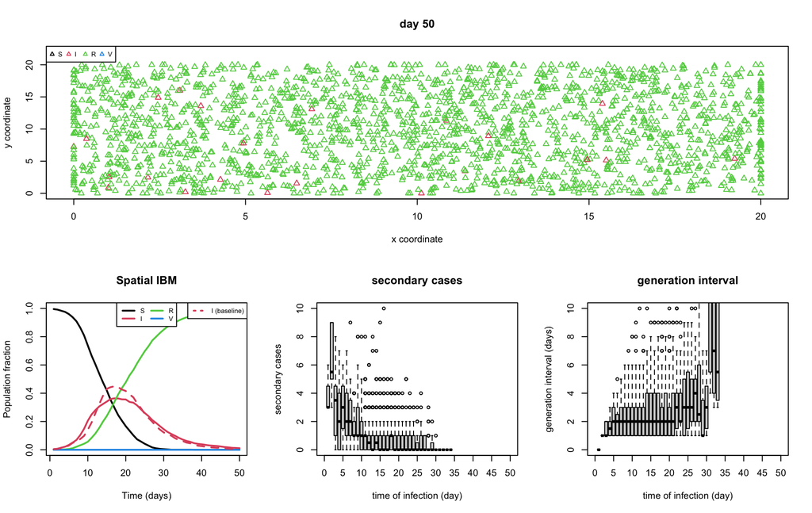

**Show output**

```
## [1] "MODEL PARAMETERS"
## [1] "pop_size: 2000"
## [1] "num_days: 50"
## [1] "num_infected_seeds: 3"
## [1] "vaccine_coverage: 0"
## [1] "apply_spatial_vaccine_refusal: FALSE"
## [1] "rng_seed: 2000"
## [1] "area_size: 20"
## [1] "max_step_size: 1"
## [1] "target_num_contacts_day: 10"
## [1] "max_contact_distance: 2"
## [1] "num_days_infected: 7"
## [1] "transmission_prob: 0.1"
## [1] "plot_time_delay: 0"
## [1] "-------------"
## [1] "MODEL RESULTS"
## [1] "total incidence: 100%   [baseline: 100%]"
## [1] "Peak prevalence: 36%   [baseline: 45%]"
## [1] "Peak day:        17    [baseline: 17]"
## [1] "Total run time:  3s"
```